# VIEWpoly: a visualization tool to integrate and explore results of polyploid genetic analysis

#### Breeding values

This feature is only available for software **QTLpoly**. Only the effects of the selected QTL in the QTL profile graphic are considered to estimate the breeding values.

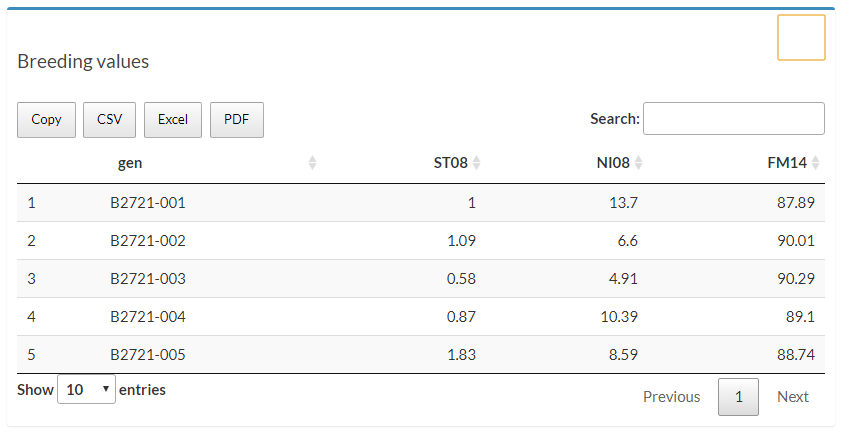

You can download the tables in VIEWpoly by clicking on the top buttons. CSV, Excel and PDF formats are available. `Copy` will copy the table to your clipboard.

#### QTL summary

VIEWpoly also provides a table with some of the main information about the selected QTL. This table also changes according to the software used to evaluate the QTL.

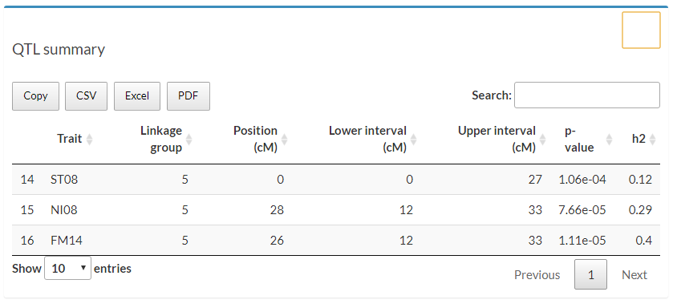

# VIEWgenome: the Genome Browser

This module has the goal to relate the QTL position in the linkage map with the available genomic information.

### Select phenotypes and linkage group

The visualization here is made defining a range in the `Map range (cM)` session by chromosome. Therefore, you can select only one chromosome to be visualized at the time. You can also select the phenotypes then the QTL positions and confidence interval are plotted just below the range. The QTL profile graphic will be also available in the `QTL profile` session.

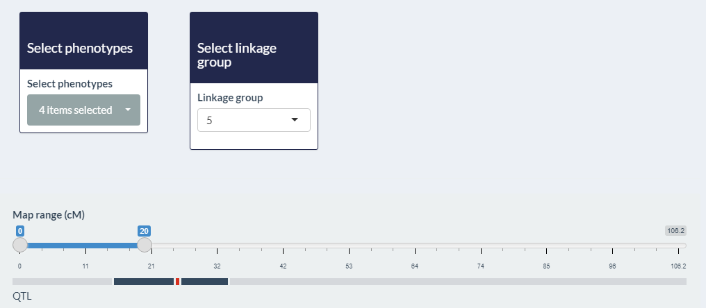

### QTL profile

Click on the `+` on the right corner of the `QTL profile` session to access a plotly graphic with the QTL significance profile.

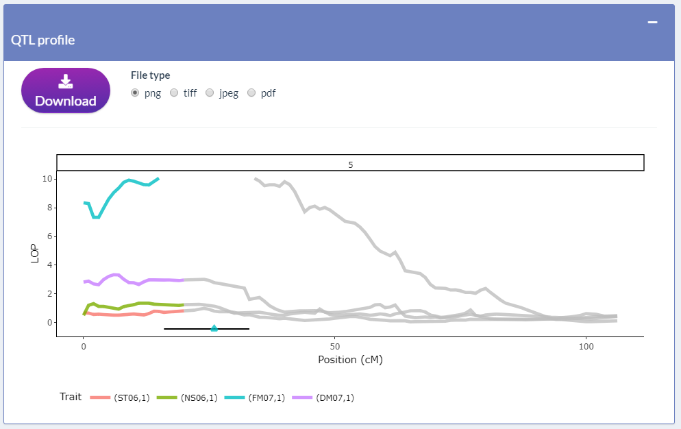

### Linkage Map x Physical

A scatterplot of the genetic versus the physical positions is displayed to highlight the relationship between the genetic map, the reference genome, the QTL positions and intervals, and the recombination rate along the chromosomes.

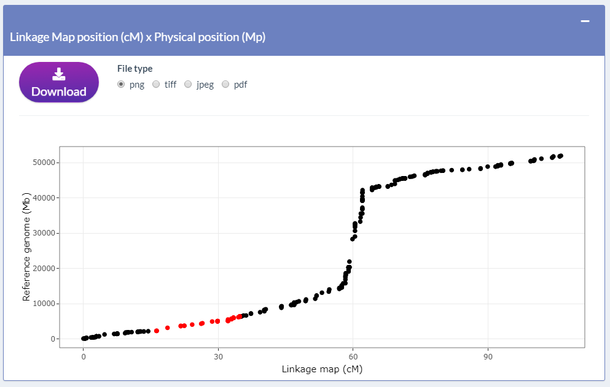

### JBrowseR

If you uploaded the genome information in the `Input data` tab, you can click on `Open JBrowseR` to visualize the genome and all the tracks according to the files uploaded:

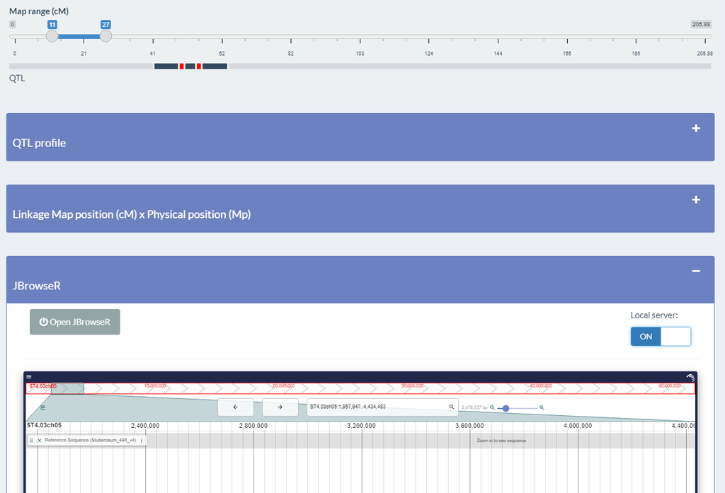

The range in the genome is set from the position of the first marker e to the position of the last marker in the selected linkage map range.

Changing the range:

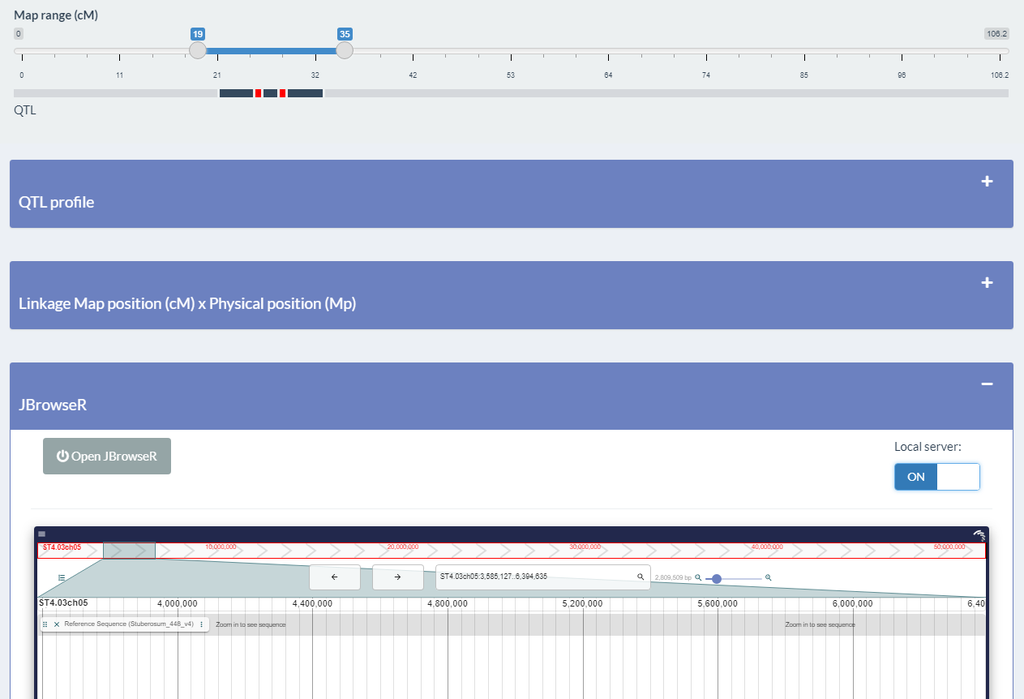

You can also explore all the JBrowse features by clicking on the buttons inside the window.

For example, zoom in:

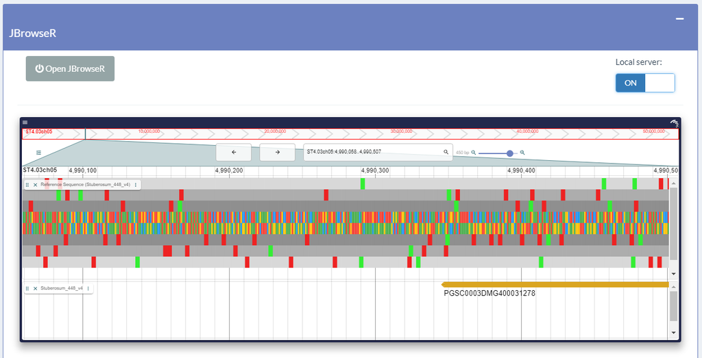

Access the menu clicking in the upper left corner:

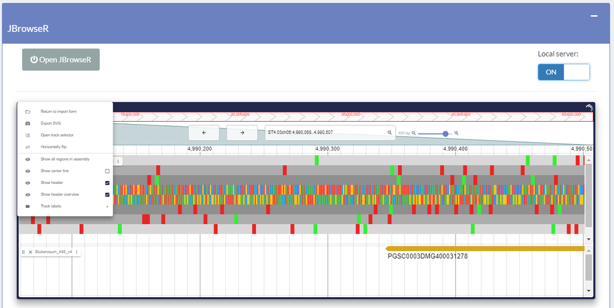

For further information about the JBrowseR features, please access [its documentation](https://jbrowse.org/jb2/docs/).

VIEWpoly creates a local server to host the genome files to JBrowseR to be able to access it. Before exiting the app or changing the genome file you must turn off the generated server by clicking on the button `Local server` session. If not, the server will only be off when you close or restart R.

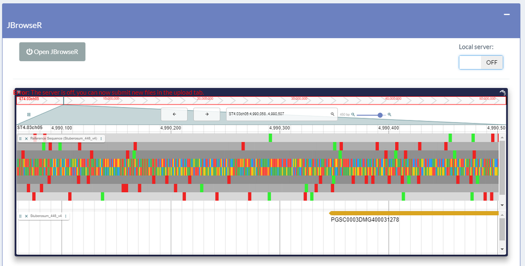

### Annotation table

If you uploaded the GFF3 file in the `Input data` session, a table will be available with annotation information inside the range selected in the linkage map.

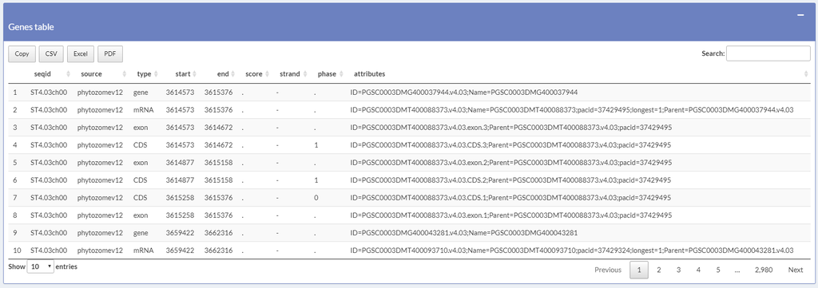

# VIEWmap: the Map Browser

This module’s goal is to provide tools to explore the linkage map proprieties. The sessions to select the phenotypes and the linkage group and to display the QTL profile are the same already described in the `QTL Browser`

### Map

In this session, it is plotted the parent’s haplotypes and linkage map related to the range selected in the `map range (cM)`. If the reference and alternative alleles information are present in the uploaded linkage map files, the variants are represented with different colors for each nucleotide (A, T, C, and G) or indel (-). If this information is not present, red and white will differentiate the biallelic sites. The dots position and color represent the dosage number.

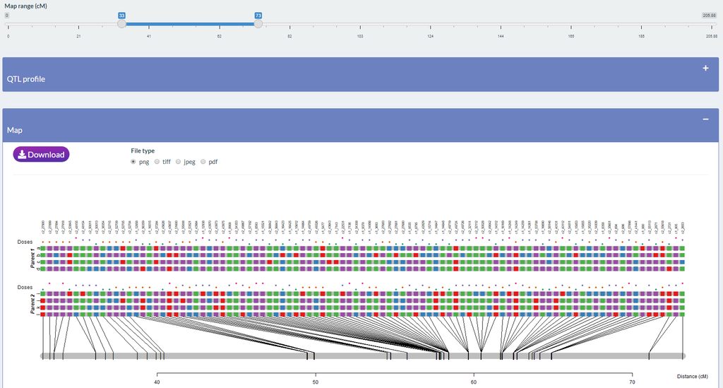

#### Parents haplotypes table

The parents haplotypes information used to build the graphic can be download in this session in table format:

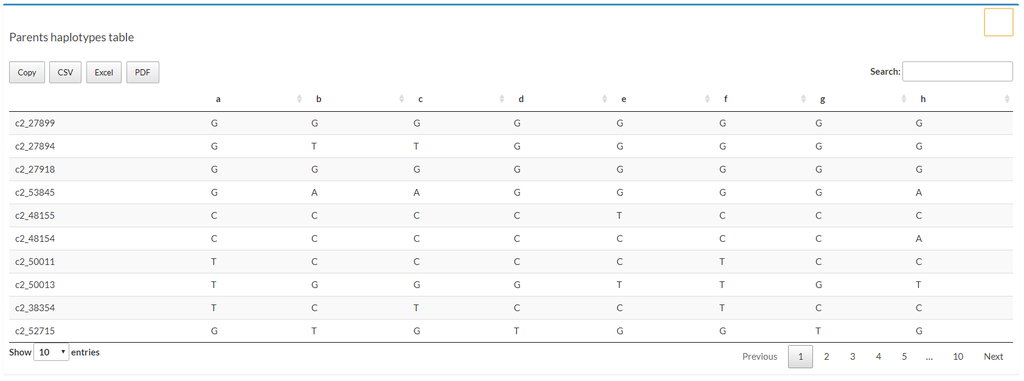

### Map summary

VIEWpoly also provides a table with the linkage map main characteristics:

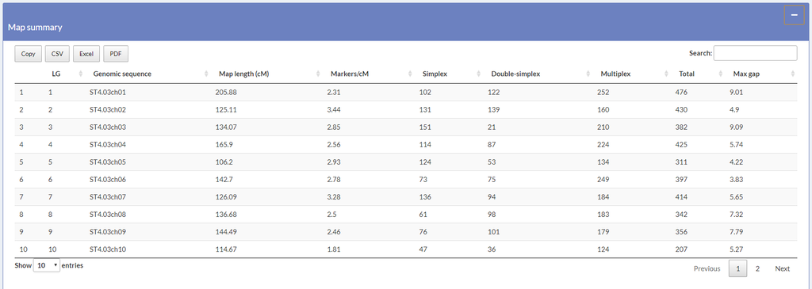

And the linkage map draw:

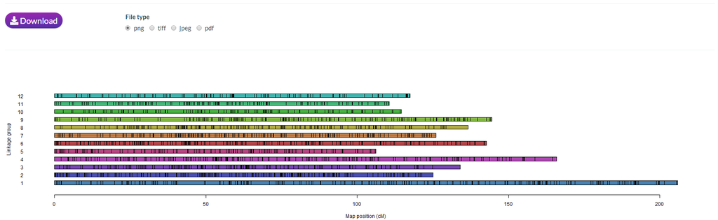

# Help us to improve

If you find issues using VIEWpoly, write to us in the issues tab in [VIEWpoly github page](https://github.com/mmollina/viewpoly) or through the email: chtaniguti@tamu.edu.

# References

Amadeu, Rodrigo R, Patricio R Muñoz, Chaozhi Zheng, and Jeffrey B Endelman. 2021. “QTL mapping in outbred tetraploid (and diploid) diallel populations.” *Genetics* 219 (3). https://doi.org/10.1093/genetics/iyab124.

Bourke, Peter M, Geert van Geest, Roeland E Voorrips, Johannes Jansen, Twan Kranenburg, Arwa Shahin, Richard G F Visser, Paul Arens, Marinus J M Smulders, and Chris Maliepaard. 2018. “polymapR—linkage analysis and genetic map construction from F1 populations of outcrossing polyploids.” *Bioinformatics* 34 (20): 3496–3502. https://doi.org/10.1093/bioinformatics/bty371.

Bourke, Peter M, Roeland E Voorrips, Christine A Hackett, Geert van Geest, Johan H Willemsen, Paul Arens, Marinus J M Smulders, Richard G F Visser, and Chris Maliepaard. 2021. “Detecting quantitative trait loci and exploring chromosomal pairing in autopolyploids using polyqtlR.” *Bioinformatics* 37 (21): 3822–29. https://doi.org/10.1093/bioinformatics/btab574.

Mollinari, Marcelo, Olokulu Bode, Pereira Guilhereme da S., Dorcus Gemenet, Craig Yencho, and Zhao-Bang Zeng. 2019. “Construction of an Integrated High-Density Map in Hexaploid Sweetpotato Using MAPpoly,” no. in preparation.

Pereira, Guilherme da Silva, Dorcus C. Gemenet, Marcelo Mollinari, Bode Olukolu, Federico Diaz, Veronica Mosquera, Wolfgang Gruneberg, Awais Khan, Craig Yencho, and and Zhao-Bang Zeng. 2019. “Multiple QTL Mapping in Autopolyploids: A Random-Effect Model Approach with Application in a Hexaploid Sweetpotato Full-Sib Population,” no. Submited. https://doi.org/10.1101/62295.